# Problem Set #3 STATS 506

Author

Jun Su

**GitHub Repository:** sujun-cmd/506hw03

### Q1. NHANES Tympanometric Width

```r
library(haven)
library(dplyr)
library(readr)
library(stringr)
library(DBI)
library(RSQLite)
library(microbenchmark)
library(emmeans)
library(knitr)
aux <- read_xpt("data/AUX_I.XPT")
demo <- read_xpt("data/DEMO_I.XPT")
nhanes <- merge(
  aux,
  demo,
  by = "SEQN",
  all = FALSE
)

dim(nhanes)
```

```
[1] 4582  119
```

After reviewing the official NHANES codebook, I found that the numeric missing-value codes are 7 and 9 for DMDCITZN, and 77 and 99 for INDHHIN2; RIAGENDR and DMDHHSZA have no special numeric missing-value codes. For INDHHIN2, codes 12 and 13 represent broad, overlapping income categories that cannot be placed precisely in the income ordering, so I treated them as missing. I also recoded 14 to 11 and 15 to 12 to preserve the ascending order of the remaining income categories.

```r
nhanes$DMDCITZN[nhanes$DMDCITZN %in% c(7, 9)] <- NA
nhanes$INDHHIN2[nhanes$INDHHIN2 %in% c(77, 99)] <- NA
nhanes$gender <- factor(
  nhanes$RIAGENDR,
  levels = c(1, 2),
  labels = c("Male", "Female")
)

nhanes$citizenship <- factor(
  nhanes$DMDCITZN,
  levels = c(1, 2),
  labels = c("Citizen", "Not a citizen")
)

nhanes$num_children <- nhanes$DMDHHSZA

nhanes$income <- nhanes$INDHHIN2
nhanes$income[nhanes$income %in% c(12, 13, 77, 99)] <- NA
nhanes$income[nhanes$income == 14] <- 11
nhanes$income[nhanes$income == 15] <- 12
```

```r
r1 <- glm(
  AUXTWIDR ~ gender,
  family = poisson(),
  data = nhanes
)

r2 <- glm(
  AUXTWIDR ~ gender + citizenship + num_children + income,
  family = poisson(),
  data = nhanes
)

l1 <- glm(
  AUXTWIDL ~ gender,
  family = poisson(),
  data = nhanes
)

l2 <- glm(
  AUXTWIDL ~ gender + citizenship + num_children + income,
  family = poisson(),
  data = nhanes
)
```

```r
#' Calculate McFadden's Pseudo R-squared
#'
#' @param model A fitted glm object.
#' @return McFadden's pseudo R-squared.
#'
#'
pseudo_r2 <- function(model) {
  null_model <- update(model, . ~ 1, data = model.frame(model))

  1 - as.numeric(logLik(model)) /
    as.numeric(logLik(null_model))
}#calculate r2 from poisson model

#' Extract incidence rate ratios and Wald test p-values
#'
#' @param model A fitted Poisson glm object.
#' @param model_name A character string identifying the model.
#' @return A data frame containing the name of the model and predictor,
#'   incidence rate ratios, and 2-side Wald test p-values.
get_coef_table <- function(model, model_name) {

  sm <- summary(model)$coefficients

  data.frame(
    Model = model_name,
    Predictor = rownames(sm),
    IRR = exp(sm[, "Estimate"]),
    P_value = sm[, "Pr(>|z|)"],
    row.names = NULL
  )
}

coef_table <- rbind(
  get_coef_table(r1, "1R"),
  get_coef_table(r2, "2R"),
  get_coef_table(l1, "1L"),
  get_coef_table(l2, "2L")
)

# remove intercept if you do not want to report it
coef_table <- coef_table[
  coef_table$Predictor != "(Intercept)",
]

coef_table$IRR <- round(coef_table$IRR, 3)
coef_table$P_value <- signif(coef_table$P_value, 3)

knitr::kable(
  coef_table,
  caption = "table for coefficients",
  col.names = c(
    "Model",
    "Predictor",
    "IRR",
    "p-value"
  )
)
```

table for coefficients

[output not shown]

```r
model_table <- data.frame(
  Model = c("1R", "2R", "1L", "2L"),

  Outcome = c(
    "Right ear",
    "Right ear",
    "Left ear",
    "Left ear"
  ),

  n = c(
    nobs(r1),
    nobs(r2),
    nobs(l1),
    nobs(l2)
  ),

  Pseudo_R2 = c(
    pseudo_r2(r1),
    pseudo_r2(r2),
    pseudo_r2(l1),
    pseudo_r2(l2)
  ),

  AIC = c(
    AIC(r1),
    AIC(r2),
    AIC(l1),
    AIC(l2)
  )
)

model_table$Pseudo_R2 <- round(model_table$Pseudo_R2, 4)
model_table$AIC <- round(model_table$AIC, 1)

knitr::kable(
  model_table,
  caption = "table for model statistics",
  col.names = c(
    "Model",
    "Outcome",
    "n",
    "Pseudo-R2",
    "AIC"
  )
)
```

table for model statistics

| Model | Outcome | n | Pseudo-R2 | AIC |
| --- | --- | --- | --- | --- |
| 1R | Right ear | 4149 | 0.0001 | 96618.5 |
| 2R | Right ear | 3705 | 0.0042 | 84916.0 |
| 1L | Left ear | 4103 | 0.0001 | 98685.1 |
| 2L | Left ear | 3665 | 0.0027 | 86598.0 |

```r
gender_coef <- summary(l2)$coefficients["genderFemale", ]

gender_irr <- exp(gender_coef["Estimate"])
gender_p <- gender_coef["Pr(>|z|)"]

gender_irr
```

```
Estimate
1.018746
```

```r
gender_p
```

```
    Pr(>|z|)
2.473393e-07
```

IRR = 1.018746，p = 2.47e-07< 0.05 Therefore, the null hypothesis is rejected. The expected measurement for the left ear in women is approximately 1.87% higher than in men.

```r
library(emmeans)


pred_gender <- emmeans(
  l2,
  ~ gender,
  type = "response"
)

pred_gender
```

```
 gender rate    SE  df asymp.LCL asymp.UCL
 Male   84.8 0.252 Inf      84.3      85.3
 Female 86.3 0.249 Inf      85.9      86.8

Results are averaged over the levels of: citizenship
Confidence level used: 0.95
Intervals are back-transformed from the log scale
```

```r
pairs(pred_gender)
```

```
 contrast      ratio      SE  df null z.ratio p.value
 Male / Female 0.982 0.00353 Inf    1  -5.160  <.0001

Results are averaged over the levels of: citizenship
Tests are performed on the log scale
```

The predicted left-ear tympanometric width was 84.8 for males and 86.3 for females. The difference was statistically significant (p < 0.0001), indicating that females have a slightly higher predicted left-ear tympanometric width than males.

## Q2

```r
library(DBI)
library(RSQLite)
con <- dbConnect(
  SQLite(),
  "data/sakila_master.db"
) #get the data
dbListTables(con)
```

```
 [1] "actor"                  "address"                "category"
 [4] "city"                   "country"                "customer"
 [7] "customer_list"          "film"                   "film_actor"
[10] "film_category"          "film_list"              "film_text"
[13] "inventory"              "language"               "payment"
[16] "rental"                 "sales_by_film_category" "sales_by_store"
[19] "staff"                  "staff_list"             "store"
```

```r
dbListFields(con, "customer")
```

```
[1] "customer_id" "store_id"    "first_name"  "last_name"   "email"
[6] "address_id"  "active"      "create_date" "last_update"
```

### Q2A

```r
customer <- dbGetQuery(con, "SELECT * FROM customer;")

head(customer, 5)
```

```
  customer_id store_id first_name last_name                               email
1           1        1       MARY     SMITH       MARY.SMITH@sakilacustomer.org
2           2        1   PATRICIA   JOHNSON PATRICIA.JOHNSON@sakilacustomer.org
3           3        1      LINDA  WILLIAMS   LINDA.WILLIAMS@sakilacustomer.org
4           4        2    BARBARA     JONES    BARBARA.JONES@sakilacustomer.org
5           5        1  ELIZABETH     BROWN  ELIZABETH.BROWN@sakilacustomer.org
  address_id active             create_date         last_update
1          5      1 2006-02-14 22:04:36.000 2020-12-23 07:15:11
2          6      1 2006-02-14 22:04:36.000 2020-12-23 07:15:11
3          7      1 2006-02-14 22:04:36.000 2020-12-23 07:15:11
4          8      1 2006-02-14 22:04:36.000 2020-12-23 07:15:11
5          9      1 2006-02-14 22:04:36.000 2020-12-23 07:15:11
```

```r
result_r <- customer %>% group_by(store_id) %>%
  summarise(n_customer = n(), pct_active = mean(as.numeric(active)) * 100)

result_sql <- dbGetQuery(con,
  " SELECT store_id, COUNT(customer_id) AS n_customer, AVG(active) * 100 AS pct_active FROM customer GROUP BY store_id; "
)
result_r
```

```
# A tibble: 2 × 3
  store_id n_customer pct_active
     <int>      <int>      <dbl>
1        1        326       97.5
2        2        273       97.4
```

```r
result_sql
```

```
  store_id n_customer pct_active
1        1        326   97.54601
2        2        273   97.43590
```

Then get the time benchmark

```r
library(microbenchmark)

microbenchmark(
  R = {
        customer <- dbGetQuery(con, "SELECT * FROM customer;")

        result_r <- customer %>% group_by(store_id) %>%
        summarise(n_customer = n(), pct_active = mean(as.numeric(active)) * 100)
  },

  SQL = {
    dbGetQuery(con,
       " SELECT store_id, COUNT(customer_id) AS n_customer, AVG(active) * 100 AS pct_active FROM customer GROUP BY store_id; "
      )
  },

  times = 100
)
```

```
Unit: microseconds
 expr      min       lq      mean    median       uq      max neval
    R 1654.514 1702.238 1827.6578 1717.3875 1763.943 5387.933   100
  SQL  169.330  186.181  201.2112  203.2985  208.854  306.844   100
```

### Q2B

```r
staff  <- dbGetQuery(con, "SELECT first_name, last_name, address_id FROM staff;")
address <- dbGetQuery(con, "SELECT * FROM address;")
city <- dbGetQuery(con, "SELECT * FROM city;")
country<- dbGetQuery(con, "SELECT * FROM country;")
staff_sql <- dbGetQuery(con, "SELECT staff.first_name || ' ' || staff.last_name AS name, country.country FROM staff
INNER JOIN address
  ON staff.address_id = address.address_id
INNER JOIN city
  ON address.city_id = city.city_id
INNER JOIN country
  ON city.country_id = country.country_id;")
staff_sql
```

```
          name   country
1 Mike Hillyer    Canada
2 Jon Stephens Australia
```

```r
staff_r <- staff %>% inner_join(address, by = 'address_id') %>% inner_join(city, by = 'city_id') %>% inner_join(country, by = 'country_id') %>% mutate(name = paste(first_name, last_name)) %>% select(name, country)
staff_r
```

```
          name   country
1 Mike Hillyer    Canada
2 Jon Stephens Australia
```

```r
microbenchmark(
SQL = { dbGetQuery(con, "SELECT staff.first_name || ' ' || staff.last_name AS name, country.country FROM staff
INNER JOIN address
  ON staff.address_id = address.address_id
INNER JOIN city
  ON address.city_id = city.city_id
INNER JOIN country
  ON city.country_id = country.country_id;")},

R = {
  staff  <- dbGetQuery(con, "SELECT first_name, last_name, address_id FROM staff;")
address <- dbGetQuery(con, "SELECT * FROM address;")
city <- dbGetQuery(con, "SELECT * FROM city;")
country<- dbGetQuery(con, "SELECT * FROM country;")
  staff %>% inner_join(address, by = 'address_id') %>% inner_join(city, by = 'city_id') %>% inner_join(country, by = 'country_id') %>% mutate(name = paste(first_name, last_name)) %>% select(name, country)},

  times = 100
)
```

```
Unit: microseconds
 expr      min        lq      mean   median       uq      max neval
  SQL  108.076  122.5695  138.1782  142.639  148.625  320.989   100
    R 3149.128 3235.8020 3397.4281 3277.560 3307.716 5049.027   100
```

### Q2C

```r
box_sql <- dbGetQuery(con, "SELECT DISTINCT film.title, payment.amount FROM film
INNER JOIN inventory
  ON film.film_id = inventory.film_id
INNER JOIN rental
  ON inventory.inventory_id = rental.inventory_id
INNER JOIN payment
  ON rental.rental_id = payment.rental_id WHERE payment.amount = (SELECT MAX(amount) FROM payment);")
box_sql
```

```
                  title amount
1       SCORPION APOLLO  11.99
2 FLINTSTONES HAPPINESS  11.99
3             SHOW LORD  11.99
4             TRAP GUYS  11.99
5           TIES HUNGER  11.99
6      VIRTUAL SPOILERS  11.99
7        STING PERSONAL  11.99
8           MINE TITANS  11.99
9   MIDSUMMER GROUNDHOG  11.99
```

```r
film <- dbGetQuery(con, "SELECT * FROM film;")
inventory <- dbGetQuery(con, "SELECT * FROM inventory;")
rental <- dbGetQuery(con, "SELECT * FROM rental;")
payment <- dbGetQuery(con, "SELECT * FROM payment;")
box_r <- film %>% inner_join(inventory, by = "film_id") %>% inner_join(rental, by = "inventory_id") %>%
  inner_join(payment, by = "rental_id") %>% filter(amount == max(amount)) %>% select(title, amount) %>%
  distinct()
box_r
```

```
                  title amount
1 FLINTSTONES HAPPINESS  11.99
2   MIDSUMMER GROUNDHOG  11.99
3           MINE TITANS  11.99
4       SCORPION APOLLO  11.99
5             SHOW LORD  11.99
6        STING PERSONAL  11.99
7           TIES HUNGER  11.99
8             TRAP GUYS  11.99
9      VIRTUAL SPOILERS  11.99
```

```r
microbenchmark(
SQL = { dbGetQuery(con, "SELECT DISTINCT film.title, payment.amount FROM film
INNER JOIN inventory
  ON film.film_id = inventory.film_id
INNER JOIN rental
  ON inventory.inventory_id = rental.inventory_id
INNER JOIN payment
  ON rental.rental_id = payment.rental_id WHERE payment.amount = (SELECT MAX(amount) FROM payment);")
},
R = {
film <- dbGetQuery(con, "SELECT * FROM film;")
inventory <- dbGetQuery(con, "SELECT * FROM inventory;")
rental <- dbGetQuery(con, "SELECT * FROM rental;")
payment <- dbGetQuery(con, "SELECT * FROM payment;")
box_r <- film %>% inner_join(inventory, by = "film_id") %>% inner_join(rental, by = "inventory_id") %>%
  inner_join(payment, by = "rental_id") %>% filter(amount == max(amount)) %>% select(title, amount) %>%
  distinct()
}
)
```

```
Unit: milliseconds
 expr       min        lq      mean   median        uq       max neval
  SQL  1.060137  1.088099  1.202125  1.16071  1.279979  2.262503   100
    R 34.544755 35.168755 36.507762 35.48062 37.091532 75.117863   100
```

The SQL approach is much faster, with an average runtime of about 1 ms compared with 37 ms for the R approach.

## Q3

```r
aus <- read_csv("data/au-500.csv")
com_data <- aus %>%
  filter(endsWith(web, ".com"))

perc_com <- nrow(com_data) / nrow(aus) * 100
perc_com
```

```
[1] 0
```

There are no websites ending in `.com`, so the percentage is **0%**. In fact, all websites in `au-500.csv` end in `.com.au`.

```r
aus$emailDomain <- sub(".*@", "", aus$email)
count(aus, emailDomain,sort = TRUE)
```

```
# A tibble: 203 × 2
   emailDomain         n
   <chr>           <int>
 1 hotmail.com       114
 2 gmail.com         102
 3 yahoo.com          84
 4 agar.net.au         1
 5 agney.net.au        1
 6 ahlborn.com.au      1
 7 albrough.com.au     1
 8 alerte.com.au       1
 9 amedro.net.au       1
10 andrion.com.au      1
# ℹ 193 more rows
```

The most common domain name is hotmail.com, which appears 114 times.

```r
aus$has_NAC <- grepl("[^A-Za-z, ]", aus$company_name)
percent_NAC <- sum(aus$has_NAC) / nrow(aus)
percent_NAC
```

```
[1] 0.09
```

```r
aus$has_NACnand <- grepl("[^A-Za-z, &]", aus$company_name)
percent_NACnand <- sum(aus$has_NACnand) / nrow(aus)
percent_NACnand
```

```
[1] 0.008
```

9% of all company names contain a non-alphabetic character excluding commas and whitespace. 0.8% of all company names contain a non-alphabetic character excluding commas, ‘&’ and whitespace.

```r
aus$phone1 <- paste0(
  substr(gsub("-", "", aus$phone1), 1, 4),
  "-",
  substr(gsub("-", "", aus$phone1), 5, 7),
  "-",
  substr(gsub("-", "", aus$phone1), 8, 10)
)

aus$phone2 <- paste0(
  substr(gsub("-", "", aus$phone2), 1, 4),
  "-",
  substr(gsub("-", "", aus$phone2), 5, 7),
  "-",
  substr(gsub("-", "", aus$phone2), 8, 10)
)
head(aus, 10)
```

```
# A tibble: 10 × 14
   first_name last_name  company_name    address city  state post  phone1 phone2
   <chr>      <chr>      <chr>           <chr>   <chr> <chr> <chr> <chr>  <chr>
 1 Rebbecca   Didio      Brandt, Jonath… 171 E … Leith TAS   7315  0381-… 0458-…
 2 Stevie     Hallo      Landrum Tempor… 22222 … Pros… QLD   4613  0799-… 0497-…
 3 Mariko     Stayer     Inabinet, Macr… 534 Sc… Hamel WA    6215  0855-… 0427-…
 4 Gerardo    Woodka     Morris Downing… 69206 … Talm… NSW   2640  0260-… 0443-…
 5 Mayra      Bena       Buelt, David L… 808 Gl… Lane… NSW   1595  0214-… 0453-…
 6 Idella     Scotland   Artesian Ice &… 373 La… Cart… WA    6316  0878-… 0451-…
 7 Sherill    Klar       Midway Hotel    87 Syl… Nyam… WA    6258  0865-… 0427-…
 8 Ena        Desjardiws Selsor, Robert… 60562 … Bend… NSW   2803  0252-… 0415-…
 9 Vince      Siena      Vincent J Pett… 70 S 1… Purr… QLD   4356  0731-… 0411-…
10 Theron     Jarding    Prentiss, Paul… 8839 V… Blan… SA    5357  0868-… 0461-…
# ℹ 5 more variables: email <chr>, web <chr>, emailDomain <chr>, has_NAC <lgl>,
#   has_NACnand <lgl>
```

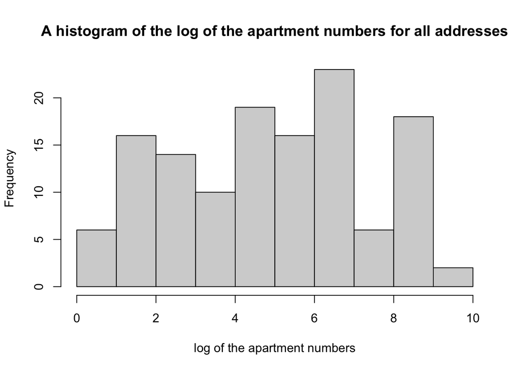

```r
#if not end with numbers, they will be NA
aus$apt_num <- as.numeric(
     str_extract(aus$address, "\\d+$")
  )

hist(log(aus$apt_num), main = 'A histogram of the log of the apartment numbers for all addresses', xlab = 'log of the apartment numbers')
```

```r
apt <- aus$apt_num[aus$apt_num > 0]
first_digit <- as.numeric(substr(as.character(apt), 1, 1))
observed <- table(first_digit)
observed_prob <- table(first_digit) / sum(table(first_digit))
observed_prob
```

```
first_digit
         1          2          3          4          5          6          7
0.09230769 0.14615385 0.12307692 0.10000000 0.10769231 0.13846154 0.06153846
         8          9
0.08461538 0.14615385
```

```r
digits <- 1:9
benford_prob <- log10(1 + 1 / digits)
benford_prob
```

```
[1] 0.30103000 0.17609126 0.12493874 0.09691001 0.07918125 0.06694679 0.05799195
[8] 0.05115252 0.04575749
```

They don’t appear to follow the Benford’s law.

```r
chisq.test(
  observed,
  p = benford_prob
)
```

```
    Chi-squared test for given probabilities

data:  observed
X-squared = 62.268, df = 8, p-value = 1.67e-10
```

Runnning a chi-square test, the p value is 1.67e-10 far smaller than 0.05, so we reject the null hypothesis that the apartment number follows the Benford’s law. The apartment numbers would not pass as real data.

## Attribution of Sources

OpenAI ChatGPT was used to review my draft against the assignment requirements and to explain the help documents. I wrote, reviewed, and verified the final code myself.